# Alex’s R Reference Guide

Alex Low

2022-12-11

# Loading Data and Packages

## library() and require()

Many projects in R will require you to make use of external packages. The library() and require() commands load these external packages into your environment, allowing you to use the associated data and commands. Though in most cases functionally similar, the two differ in that the library() command will stop your code from running if the required package is unavailable or has not been installed, while require() will not, but will silently return a boolean value based on whether the package is available.

```r
# Examples of proper library and require syntax
library(here)
require(palmerpenguins)
```

## loading data using here() and read.csv()

To load data from external files, we typically make use of there here() function in the here package loaded previously. This function makes loading data more convenient by allowing us to reference relative file paths, rather than absolute ones. When used, the here() command references the top-level directory of the current r project. If project data is stored in this directory when it is shared, collaborators are easily able to load and use data without having to change file paths.

```r
# Using the here() function, we list all the files in our "data" folder within the project directory
list.files(here("data"))
```

```
## [1] "Backup of Quantitative_Data_Set.xlk" "bird.sta.csv"
## [3] "birds_metadata.pdf"                  "catrate.csv"
## [5] "delomys.csv"                         "ginkgo_data_2022.csv"
## [7] "hab.sta.csv"                         "Quantitative_Data_Set.xlsx"
## [9] "rope.csv"
```

As our data commonly comes in csv format, we also make frequent use of the read.csv() command, which is able to read in data to our environment from external csv files.

```r
# Reading in a csv file "ginkgo data 2022" from our project data folder
ginkgo_data <- data.frame(read.csv(here("data","ginkgo_data_2022.csv")))
head(ginkgo_data)
```

```
##   site_id seeds_present max_width max_depth notch_depth petiole_length
## 1     216         FALSE        85        59          12             91
## 2     216         FALSE        72        54           0             56
## 3     216         FALSE        64        42           0             71
## 4     216         FALSE        76        48           0             44
## 5     216         FALSE        85        50           5             40
## 6     216         FALSE        75        46           7             50
```

# Data Structures

## c()

The function c() combines or concatenates its arguments into a vector (a 1-dimensional data structure consisting of 1 or more elements). Do note, however, that all elements must be of the same type. Here’s two examples using numeric and character types:

```r
# Create a vector of numbers:
num_vec  = c(1, 4, 8, 9, 13)

# Create a vector of characters:
char_vec = c("a", "fish", "data is cool")
```

I can show the contents of a vector by typing the name of the vector, or using the print() function.

```r
# Typing the name of the vector into the console prints the contents
num_vec
```

```
## [1]  1  4  8  9 13
```

```r
# The print() function accomplishes the same task:
print(char_vec)
```

```
## [1] "a"            "fish"         "data is cool"
```

## length()

The length() function is used to either retrieve the length of a vector or set it manually.

```r
# Getting the length of a vector using length()
sample_vec = c(7, 8, 9)
length(sample_vec)
```

```
## [1] 3
```

```r
# Setting the length of a vector using length()
length(sample_vec) = 5
sample_vec
```

```
## [1]  7  8  9 NA NA
```

## matrix()

The matrix() function is used to create a 2d data structure, a “list of lists.” This function takes arguments for a 1d set of data, along with the number of rows(nrow,) columns(ncol,) and byrow(true/false) which determines whether the matrix is populated by rows or by columns.

```r
#creating a 1d vector with values 1-9
sample_vec = c(1:9)
sample_vec
```

```
## [1] 1 2 3 4 5 6 7 8 9
```

```r
#creating a 3x3 matrix with values 1-9, populated by row
sample_mat = matrix(sample_vec, 3, 3, byrow=TRUE)
sample_mat
```

```
##      [,1] [,2] [,3]
## [1,]    1    2    3
## [2,]    4    5    6
## [3,]    7    8    9
```

## data.frame()

Though matricies are helpful, they are restricted by the sample problem as vectors- they can only hold one type of data value, like characters or text. In the real world however, many datasets are a beautiful mix of all kinds of types. Data frames allow us to store and operate on 1d and 2d datasets where all values are not necessarily of the same type. Because of their flexibility, data frames are the preferred way of storing and operating on data in R.

```r
##creating a dataset of all different types through use of data.frame()
sample_1d = data.frame(c(1, "apple", TRUE))
sample_1d
```

```
##   c.1...apple...TRUE.
## 1                   1
## 2               apple
## 3                TRUE
```

## nrow()

The nrow() function can be used to find the number of rows in a given 2d dataset. Similarly to the length() function, it can also be used to set the number of rows manually, filling in NA values for newly created rows.

```r
head(ginkgo_data)
```

```
##   site_id seeds_present max_width max_depth notch_depth petiole_length
## 1     216         FALSE        85        59          12             91
## 2     216         FALSE        72        54           0             56
## 3     216         FALSE        64        42           0             71
## 4     216         FALSE        76        48           0             44
## 5     216         FALSE        85        50           5             40
## 6     216         FALSE        75        46           7             50
```

```r
nrow(ginkgo_data)
```

```
## [1] 220
```

## ncol()

The ncol() function can be used to find the number of columns in a given 2d dataset. Similarly to the length() function, it can also be used to set the number of columns manually, filling in NA values for newly created columns.

```r
head(ginkgo_data)
```

```
##   site_id seeds_present max_width max_depth notch_depth petiole_length
## 1     216         FALSE        85        59          12             91
## 2     216         FALSE        72        54           0             56
## 3     216         FALSE        64        42           0             71
## 4     216         FALSE        76        48           0             44
## 5     216         FALSE        85        50           5             40
## 6     216         FALSE        75        46           7             50
```

```r
ncol(ginkgo_data)
```

```
## [1] 6
```

## dim()

The dim() function can be used to find the dimensions of a given 2d dataset, in rows x columns. Again like the length() function, it can set the dimensions manually, filling in NA values for new rows and columns.

```r
head(ginkgo_data)
```

```
##   site_id seeds_present max_width max_depth notch_depth petiole_length
## 1     216         FALSE        85        59          12             91
## 2     216         FALSE        72        54           0             56
## 3     216         FALSE        64        42           0             71
## 4     216         FALSE        76        48           0             44
## 5     216         FALSE        85        50           5             40
## 6     216         FALSE        75        46           7             50
```

```r
dim(ginkgo_data)
```

```
## [1] 220   6
```

# Subsetting

## Subsetting by name

Using the $ operator, we can subset a given dataset by using the name of a column. Say, for example, that we were only interested in the notch depth attribute of our samples

```r
head(ginkgo_data)
```

```
##   site_id seeds_present max_width max_depth notch_depth petiole_length
## 1     216         FALSE        85        59          12             91
## 2     216         FALSE        72        54           0             56
## 3     216         FALSE        64        42           0             71
## 4     216         FALSE        76        48           0             44
## 5     216         FALSE        85        50           5             40
## 6     216         FALSE        75        46           7             50
```

```r
ginkgo_data$notch_depth
```

```
##   [1] 12.0  0.0  0.0  0.0  5.0  7.0  2.0  0.0  3.0  9.0  4.0  3.0  3.0  6.0  2.0
##  [16] 16.0  6.0 10.0  1.0  7.0  4.0  2.0  0.0  1.0  1.0  0.0  2.0  1.0  2.0  0.0
##  [31]  2.0  1.0  2.0  4.0  1.0  5.0  1.0 19.0 27.0  1.0 14.0  6.0  1.0  9.0  5.0
##  [46]  3.0 12.0  4.0 21.0  2.0  1.0  0.5  2.0  3.0  0.5  2.5  1.0  3.0  3.0  0.0
##  [61]  0.0  5.0  0.0  4.0  0.0  0.0  0.0 15.0  0.0  9.0  0.0  0.0  2.0  4.0  0.0
##  [76]  0.0  1.0  8.0  3.0  0.0  0.0 10.0  0.0  0.0  0.0  9.0  0.0  0.0  0.0  0.0
##  [91]  5.0  0.0  0.0  1.0  1.0  0.0  0.0  0.0  0.0  0.0  0.0  2.0  0.0  0.0  0.0
## [106]  0.0  0.0  0.0  0.0  0.0  0.0  0.0  2.0  0.0  2.0  0.0 31.0  0.0  0.0 13.0
## [121] 19.0  4.0 10.0  8.0  0.0  0.0  0.0 22.0  6.0  5.0  6.0  8.0  4.0  2.0  0.0
## [136]  0.0  0.0  6.0  0.0  0.0  0.0 15.0  4.0 15.0  0.0  0.0  0.0 22.0  0.0  0.0
## [151]  4.0 22.0 11.0 11.0 10.0 16.0  0.0  7.0  2.0  6.0  5.0  8.0  5.0  6.0 39.0
## [166]  0.0  3.0  0.0  0.0  0.0  3.0  6.0  8.0  2.0  4.0  0.0  1.0  6.0  3.0  0.0
## [181] 12.0  6.0  7.0  1.0  3.0  1.0  2.0  2.0  1.5  3.0  0.0  0.0  3.0  0.0 10.0
## [196]  0.0  0.0  0.0  4.0  0.0  5.0  7.0 33.0 38.0 15.0 23.0  2.0  9.0  0.0 39.0
## [211] 24.0 18.0 54.0 30.0 28.0  3.0 43.0 32.0 28.0 92.0
```

## Subsetting by position

Another way we can subset a given dataset is by referencing the coordinate position(s) of the data we are interested in. using the [] operator, we can pick out data of specified rows and columns using the syntax: data[row,col]

```r
head(ginkgo_data)
```

```
##   site_id seeds_present max_width max_depth notch_depth petiole_length
## 1     216         FALSE        85        59          12             91
## 2     216         FALSE        72        54           0             56
## 3     216         FALSE        64        42           0             71
## 4     216         FALSE        76        48           0             44
## 5     216         FALSE        85        50           5             40
## 6     216         FALSE        75        46           7             50
```

```r
#selecting the entire first row of the data
ginkgo_data[1,]
```

```
##   site_id seeds_present max_width max_depth notch_depth petiole_length
## 1     216         FALSE        85        59          12             91
```

```r
#selecting the element in row 2, column 3
ginkgo_data[2,3]
```

```
## [1] 72
```

```r
#selecting the entire 3rd column of the data
ginkgo_data[,3]
```

```
##   [1]  85  72  64  76  85  75  72  81  87  87  94  92  70  84  61 102  82  64
##  [19]  53  66  69  55  56  64  60  59  57  53  68  56  75  63  82  83  60  67
##  [37]  75  92 110  54  77  59  51 100  92  77  99  62  80  86  63  79  91  72
##  [55]  64  53  71  61  70  93  75  87  86  87  95  88  85  95  95  52  84  74
##  [73]  87  76  57  92  94  79  97  50 100  97  63  96  97  70  83  80  85 100
##  [91] 112 115  83 106  95  80 120  76  50  90  94  69  93  59  60 103  95  90
## [109]  80  90 106  98  73  89  65  83 116  90  86 104  92 103 100  91 102  99
## [127]  98 104  80  68  62  77  86  72  70  63  72  65  69  67  35  67  63  71
## [145]  77  60  70  69  55  72  84 106  61 114  95  86  60  78  86  91  79  95
## [163]  72 102  72 107  95  91  94  90  98  63  58  67  92  75  74  73  73  94
## [181]  76  86  78  74  89  77  80  71  69  81  39  60  50  47  52  61  56  45
## [199]  64  42 103  84 118 120 100 111 104  94  78  70  92  48  79  91 111  44
## [217] 117  93 101 145
```

## Subsetting using subset()

Finally, another main way to subset a given dataset is to use the subset() function, which returns rows, columns, etc, that meet certain specified conditions.

```r
#palmer penguins data
penguins
```

```
## # A tibble: 344 x 8
##    species island    bill_length_mm bill_depth_mm flipper_length_mm body_mass_g
##    <fct>   <fct>              <dbl>         <dbl>             <int>       <int>
##  1 Adelie  Torgersen           39.1          18.7               181        3750
##  2 Adelie  Torgersen           39.5          17.4               186        3800
##  3 Adelie  Torgersen           40.3          18                 195        3250
##  4 Adelie  Torgersen           NA            NA                  NA          NA
##  5 Adelie  Torgersen           36.7          19.3               193        3450
##  6 Adelie  Torgersen           39.3          20.6               190        3650
##  7 Adelie  Torgersen           38.9          17.8               181        3625
##  8 Adelie  Torgersen           39.2          19.6               195        4675
##  9 Adelie  Torgersen           34.1          18.1               193        3475
## 10 Adelie  Torgersen           42            20.2               190        4250
## # ... with 334 more rows, and 2 more variables: sex <fct>, year <int>
```

```r
#retrieving all data for Adelie penguins (species = Adelie)
subset(penguins, species == "Adelie")
```

```
## # A tibble: 152 x 8
##    species island    bill_length_mm bill_depth_mm flipper_length_mm body_mass_g
##    <fct>   <fct>              <dbl>         <dbl>             <int>       <int>
##  1 Adelie  Torgersen           39.1          18.7               181        3750
##  2 Adelie  Torgersen           39.5          17.4               186        3800
##  3 Adelie  Torgersen           40.3          18                 195        3250
##  4 Adelie  Torgersen           NA            NA                  NA          NA
##  5 Adelie  Torgersen           36.7          19.3               193        3450
##  6 Adelie  Torgersen           39.3          20.6               190        3650
##  7 Adelie  Torgersen           38.9          17.8               181        3625
##  8 Adelie  Torgersen           39.2          19.6               195        4675
##  9 Adelie  Torgersen           34.1          18.1               193        3475
## 10 Adelie  Torgersen           42            20.2               190        4250
## # ... with 142 more rows, and 2 more variables: sex <fct>, year <int>
```

# Numerical Data Exploration

## summary()

The summary() function provides some basic summary information on an object, depending on its type. Most commonly, this function can be used on datasets to provide some basic information on the range of values for given columns as well as on model fits to provide basic information on the relationship between variables and quality of fit

```r
head(ginkgo_data)
```

```
##   site_id seeds_present max_width max_depth notch_depth petiole_length
## 1     216         FALSE        85        59          12             91
## 2     216         FALSE        72        54           0             56
## 3     216         FALSE        64        42           0             71
## 4     216         FALSE        76        48           0             44
## 5     216         FALSE        85        50           5             40
## 6     216         FALSE        75        46           7             50
```

```r
summary(ginkgo_data)
```

```
##     site_id      seeds_present     max_width        max_depth
##  Min.   :  216   Mode :logical   Min.   : 35.00   Min.   : 24.0
##  1st Qu.: 3470   FALSE:180       1st Qu.: 67.00   1st Qu.: 45.0
##  Median : 4874   TRUE :40        Median : 80.00   Median : 53.0
##  Mean   : 5726                   Mean   : 79.95   Mean   : 53.1
##  3rd Qu.: 6719                   3rd Qu.: 93.00   3rd Qu.: 60.0
##  Max.   :12982                   Max.   :145.00   Max.   :125.0
##   notch_depth     petiole_length
##  Min.   : 0.000   Min.   : 13.00
##  1st Qu.: 0.000   1st Qu.: 45.00
##  Median : 2.000   Median : 58.00
##  Mean   : 5.977   Mean   : 59.51
##  3rd Qu.: 6.250   3rd Qu.: 71.00
##  Max.   :92.000   Max.   :126.00
```

```r
ginkgo_width_by_depth = lm(max_width~max_depth, data = ginkgo_data)
summary(ginkgo_width_by_depth)
```

```
##
## Call:
## lm(formula = max_width ~ max_depth, data = ginkgo_data)
##
## Residuals:
##     Min      1Q  Median      3Q     Max
## -63.211  -7.837   1.024   9.306  26.139
##
## Coefficients:
##             Estimate Std. Error t value Pr(>|t|)
## (Intercept)  27.8738     3.8324   7.273 6.24e-12 ***
## max_depth     0.9809     0.0702  13.973  < 2e-16 ***
## ---
## Signif. codes:  0 '***' 0.001 '**' 0.01 '*' 0.05 '.' 0.1 ' ' 1
##
## Residual standard error: 13.22 on 218 degrees of freedom
## Multiple R-squared:  0.4725, Adjusted R-squared:   0.47
## F-statistic: 195.2 on 1 and 218 DF,  p-value: < 2.2e-16
```

## mean()

The mean() function returns the arithmatic mean for a given set of data, requiring numeric inputs

```r
#using mean on a simple vector of numbers
sample_vec = c(1, 2, 3)
mean(sample_vec)
```

```
## [1] 2
```

```r
#using mean() on the max depth column of the ginkgo dataset
head(ginkgo_data$max_depth)
```

```
## [1] 59 54 42 48 50 46
```

```r
mean(ginkgo_data$max_depth)
```

```
## [1] 53.09545
```

## sd()

the sd() function returns the standard deviation for a given set of data, requiring numeric inputs

```r
#using sd() on the max depth column of the ginkgo dataset
head(ginkgo_data$max_depth)
```

```
## [1] 59 54 42 48 50 46
```

```r
sd(ginkgo_data$max_depth)
```

```
## [1] 12.7281
```

# Graphical Data Exploration

## plot()

The plot() function is used to draw basic scatterplots, and has some important arguments to keep in mind:  
x, y : the x any y arguments to be plotted against one another  
type : a string denoting the type of desired plot, “p” for points, “l” for lines, among others. points is default.  
pch : a number which designates which symbol is to be used as the “plotting character”.  
cex : a number which multiplies the size of plotted text and symbols, relative to the default  
main : the main title for the plot  
xlab : the x axis label name  
ylab : the y axis label name  
xlim : the x axis limit, i.e., the final value the x axis will include  
ylim : the y axis limit, i.e., the final value the y axis will include

```r
head(ginkgo_data)
```

```
##   site_id seeds_present max_width max_depth notch_depth petiole_length
## 1     216         FALSE        85        59          12             91
## 2     216         FALSE        72        54           0             56
## 3     216         FALSE        64        42           0             71
## 4     216         FALSE        76        48           0             44
## 5     216         FALSE        85        50           5             40
## 6     216         FALSE        75        46           7             50
```

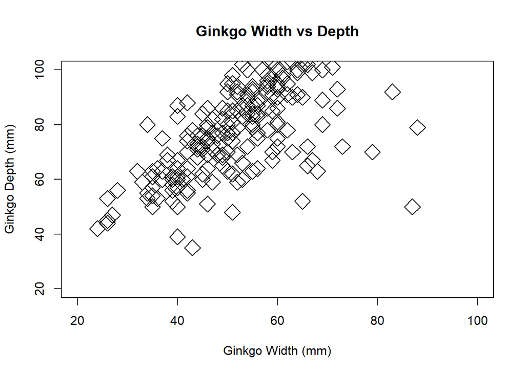

```r
#a scatter plot of ginko width vs depth, using diamond symbols (pch = 5) scaled to be 2x as large as normal, with the title "Ginkgo Width vs Depth" and appropriate x and y axis labels. Both axes will only go from 20 -> 100.
plot(ginkgo_data$max_width ~ ginkgo_data$max_depth, pch = 5, cex = 2, main = "Ginkgo Width vs Depth", xlab = "Ginkgo Width (mm)", ylab = "Ginkgo Depth (mm)", xlim = c(20,100), ylim = c(20,100))
```

## hist()

The hist() function is used to draw basic histograms. The “breaks” argument can be used to manually set the breakpoints, and will accept values for either the number of break points (i.e. breaks = 12) or a vector of exactly where the breakpoints should be set (i.e. c(1:12)). “breaks” will also accept a formula to calculate the number of breaks or a breaks vector, i.e. breaks = sum(data$column)/10

```r
head(ginkgo_data)
```

```
##   site_id seeds_present max_width max_depth notch_depth petiole_length
## 1     216         FALSE        85        59          12             91
## 2     216         FALSE        72        54           0             56
## 3     216         FALSE        64        42           0             71
## 4     216         FALSE        76        48           0             44
## 5     216         FALSE        85        50           5             40
## 6     216         FALSE        75        46           7             50
```

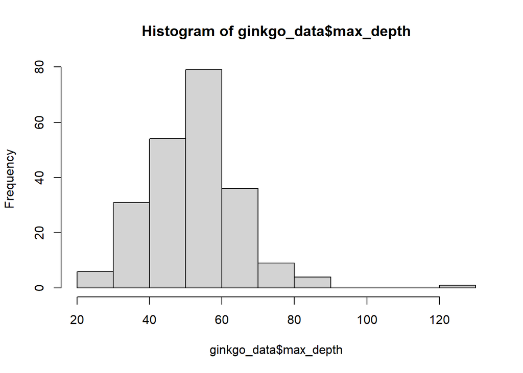

```r
#a histogram with 10 breakpoints
hist(ginkgo_data$max_depth, breaks = 10)
```

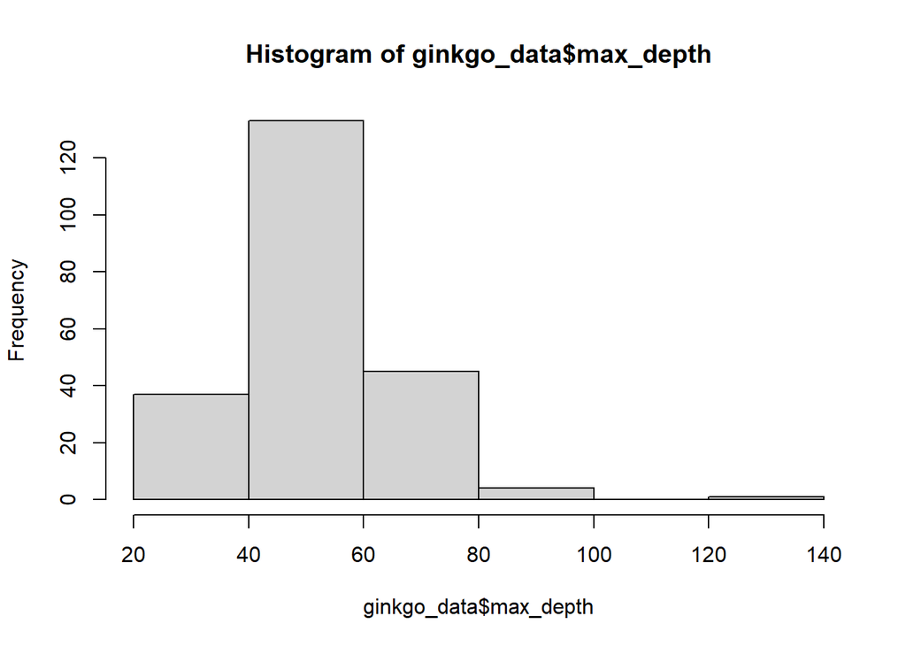

```r
#a histogram with defined breakpoints
hist(ginkgo_data$max_depth, breaks = c(20, 40, 60, 80, 100, 120, 140))
```

## boxplot()

The boxplot() funtion is used to generate basic box and whisker plots. Many of the stylistic arguments are identical to the hist() function.

```r
head(ginkgo_data$petiole_length)
```

```
## [1] 91 56 71 44 40 50
```

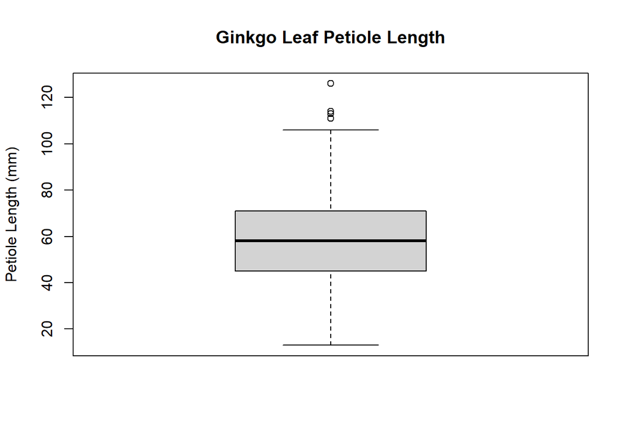

```r
#generating a boxplot of ginkgo petiole lengths
boxplot(ginkgo_data$petiole_length, ylab = "Petiole Length (mm)", main = "Ginkgo Leaf Petiole Length")
```

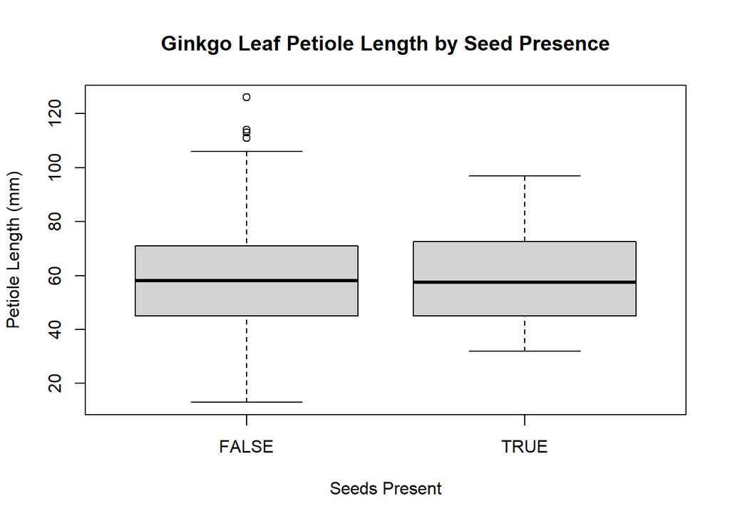

```r
#generating a boxplot of ginkgo petiole lengths, conditioned by seeds_present
boxplot(petiole_length ~ seeds_present, data=ginkgo_data, ylab = "Petiole Length (mm)", xlab = "Seeds Present",
        main = "Ginkgo Leaf Petiole Length by Seed Presence")
```

## par()

The par() argument can be used to adjust the graphical parameters of the plot viewer in the Rstudio program. Most commonly, we use this command to manually set the number of columns and rows of figures displayed in the viewer by use of the mfrows argument. By giving a vector in the form (nrows, ncols), we can set the number of rows and columns for display, which are then filled in order from left->right, top->bottom.

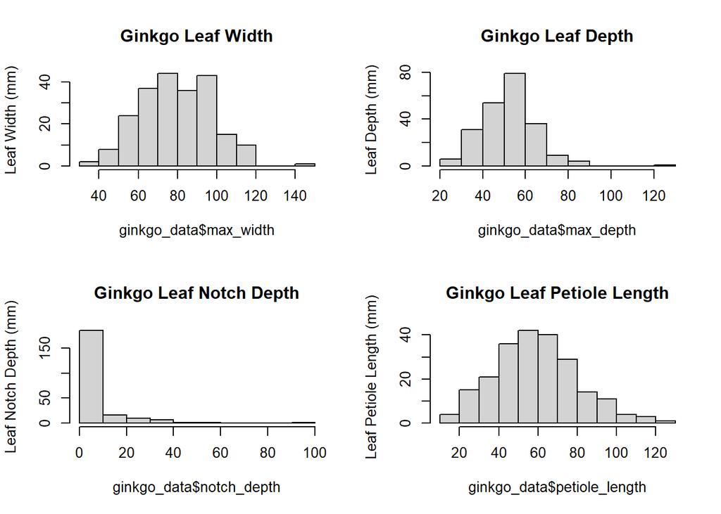

```r
#setting our display to a 2x2 grid when displaying figures
par(mfrow = c(2,2))
#displaying 4 histograms in the 2x2 grid
hist(ginkgo_data$max_width, main = "Ginkgo Leaf Width", ylab = "Leaf Width (mm)")
hist(ginkgo_data$max_depth, main = "Ginkgo Leaf Depth", ylab = "Leaf Depth (mm)")
hist(ginkgo_data$notch_depth, main = "Ginkgo Leaf Notch Depth", ylab = "Leaf Notch Depth (mm)")
hist(ginkgo_data$petiole_length, main = "Ginkgo Leaf Petiole Length", ylab = "Leaf Petiole Length (mm)")
```

# Distribution Functions

## dnorm()

The dnorm() function is used to determine relative likelihoods of observing specified values, given a normal distribution of a specified mean and standard deviation

```r
#given a normal distribution with a mean of 0 and a standard deviation of 1, what are the chances of observing a value of 0.39?
dnorm(0.39, mean = 0, sd = 1)
```

```
## [1] 0.3697277
```

```r
#how about -0.11? which is more likely?
dnorm(-0.11, mean = 0, sd = 1)
```

```
## [1] 0.396536
```

This function can also be used to create data which follows normal data of specified mean and sd:

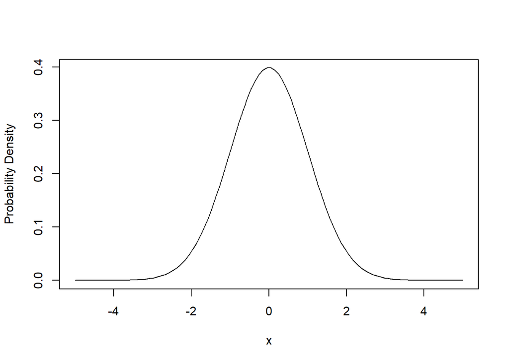

```r
#creating 100 points, ranging from -5 to 5
x = seq(from = -5, to = 5, length.out = 100)
#storing the probability values for any given x, based on the defined normal distribution
y = dnorm(x, mean = 0, sd = 1)
plot(y ~ x, type = "l", ylab = "Probability Density")
```